title: “PS5 Gapminder Data Set” author: “Rya” date: “2023-02-15” output: html_document

```r
library(tidyverse)
```

**1 Load and check data (5pt)** **You first task is to do a very simple data check:**

1. (1pt) For solving the problems, and answering the questions, create a new rmarkdown docu- ment with an appropriate title. See https://faculty.washington.edu/otoomet/info201-book/ r-markdown.html#r-markdown-rstudio-creating.
2. (2pt) Load data. How many rows/columns do we have?

```r
gapminder <- read_delim("gapminder.csv")
gapminder %>%
nrow()
```

```
## [1] 13055
```

```r
gapminder %>%
ncol()
```

```
## [1] 25
```

3. (2pt) Print a small sample of data. Does it look OK?

```r
gapminder %>%
sample_n(10)
```

```
## # A tibble: 10 × 25
##    iso3  name         iso2  region sub-r…¹ inter…²  time total…³ ferti…⁴ lifeE…⁵
##    <chr> <chr>        <chr> <chr>  <chr>   <chr>   <dbl>   <dbl>   <dbl>   <dbl>
##  1 ASM   American Sa… AS    Ocean… Polyne… <NA>     1978  3.13e4   NA       NA
##  2 SVN   Slovenia     SI    Europe Southe… <NA>     1997  1.99e6    1.25    74.7
##  3 AZE   Azerbaijan   AZ    Asia   Wester… <NA>     2019  1.00e7    1.8     73.0
##  4 MLI   Mali         ML    Africa Sub-Sa… Wester…  1967  5.71e6    7.09    30.5
##  5 GBM   <NA>         <NA>  <NA>   <NA>    <NA>     1976  6.04e4   NA       NA
##  6 ARM   Armenia      AM    Asia   Wester… <NA>     1979  3.05e6    2.54    70.9
##  7 MNG   Mongolia     MN    Asia   Easter… <NA>     2010  2.72e6    2.64    67.4
##  8 SLB   Solomon Isl… SB    Ocean… Melane… <NA>     1974  1.86e5    7.25    59.2
##  9 BMU   Bermuda      BM    Ameri… Northe… <NA>     1985  5.69e4   NA       NA
## 10 SSD   South Sudan  SS    Africa Sub-Sa… Easter…  1986  5.33e6    6.82    40.9
## # … with 15 more variables: childMortality <dbl>, youthFemaleLiteracy <dbl>,
## #   youthMaleLiteracy <dbl>, adultLiteracy <dbl>, GDP_PC <dbl>,
## #   accessElectricity <dbl>, agriculturalLand <dbl>, agricultureTractors <dbl>,
## #   cerealProduction <dbl>, fertilizerHa <dbl>, co2 <dbl>,
## #   greenhouseGases <dbl>, co2_PC <dbl>, pm2.5_35 <dbl>, battleDeaths <dbl>,
## #   and abbreviated variable names ¹`sub-region`, ²`intermediate-region`,
## #   ³totalPopulation, ⁴fertilityRate, ⁵lifeExpectancy
```

```r
# Data looks good and has many missing values
```

**2 Descriptive statistics (15pt)**

1. (3pt) How many countries are there in the dataset? Analyze all three: iso3, iso2 and name.

```r
gapminder %>%
summarize(n = n_distinct(iso3))
```

```
## # A tibble: 1 × 1
##       n
##   <int>
## 1   253
```

```r
gapminder %>%
summarize(n = n_distinct(iso2))
```

```
## # A tibble: 1 × 1
##       n
##   <int>
## 1   249
```

```r
gapminder %>%
summarize(n = n_distinct(name))
```

```
## # A tibble: 1 × 1
##       n
##   <int>
## 1   250
```

2. If you did this correctly, you saw that there are more names than iso-2codes, and there are even more iso3 -codes. What is going on? Can you find it out?
1. (5pt) Find how many names are there for each iso-2 code. Are there any iso-2 codes that correspond to more than one name? What are these countries?

```r
gapminder %>%
group_by(iso2) %>%
summarize(name_count = n_distinct(name)) %>%
arrange(desc(name_count))
```

```
## # A tibble: 249 × 2
##    iso2  name_count
##    <chr>      <int>
##  1 <NA>           2
##  2 AD             1
##  3 AE             1
##  4 AF             1
##  5 AG             1
##  6 AI             1
##  7 AL             1
##  8 AM             1
##  9 AO             1
## 10 AQ             1
## # … with 239 more rows
```

```r
gapminder %>%
filter(is.na(iso2)) %>%
distinct(name)
```

```
## # A tibble: 2 × 1
##   name
##   <chr>
## 1 <NA>
## 2 Namibia
```

2. (5pt) Now repeat the same for name and iso3-code. Are there country names that have more than one iso3-code? What are these countries? Hint: two of these entitites are CHANISL and NLD CURACAO.

```r
gapminder %>%
group_by(name) %>%
summarize(name_count = n_distinct(iso3)) %>%
arrange(desc(name_count))
```

```
## # A tibble: 250 × 2
##    name           name_count
##    <chr>               <int>
##  1 <NA>                    4
##  2 Afghanistan             1
##  3 Åland Islands           1
##  4 Albania                 1
##  5 Algeria                 1
##  6 American Samoa          1
##  7 Andorra                 1
##  8 Angola                  1
##  9 Anguilla                1
## 10 Antarctica              1
## # … with 240 more rows
```

```r
gapminder %>%
filter(is.na(name)) %>%
distinct(iso3)
```

```
## # A tibble: 4 × 1
##   iso3
##   <chr>
## 1 CHANISL
## 2 GBM
## 3 KOS
## 4 NLD_CURACAO
```

3. (2pt) What is the minimum and maximum year in these data?

```r
gapminder %>%
  select(time) %>%
  filter(!is.na(time)) %>%
  summarize(min(time), (max(time)))
```

```
## # A tibble: 1 × 2
##   `min(time)` `(max(time))`
##         <dbl>         <dbl>
## 1        1960          2019
```

**3 CO2 emissions (30pt)** **Next, let’s analyze CO2 emissions.**

1. (2pt) How many missing co2 emissions are there for each year? Analyze both missing CO2 and co2_PC. Which years have most missing data?

```r
gapminder %>%
  group_by(time) %>%
  summarize(missing_co2 = sum(is.na(co2)), missing_co2_PC = sum(is.na(co2_PC))) %>%
  arrange(desc(missing_co2)) %>%
  head(10)
```

```
## # A tibble: 10 × 3
##     time missing_co2 missing_co2_PC
##    <dbl>       <int>          <int>
##  1  2017         217            217
##  2  2018         217            217
##  3  2019         217            217
##  4  1960          60             60
##  5  1961          60             60
##  6  1962          58             58
##  7  1963          57             57
##  8  1964          51             51
##  9  1965          51             51
## 10  1966          51             51
```

2. (5pt) Make a plot of total CO2 emissions over time for the U.S, China, and India. Add a few more countries of your choice. Explain what do you see.

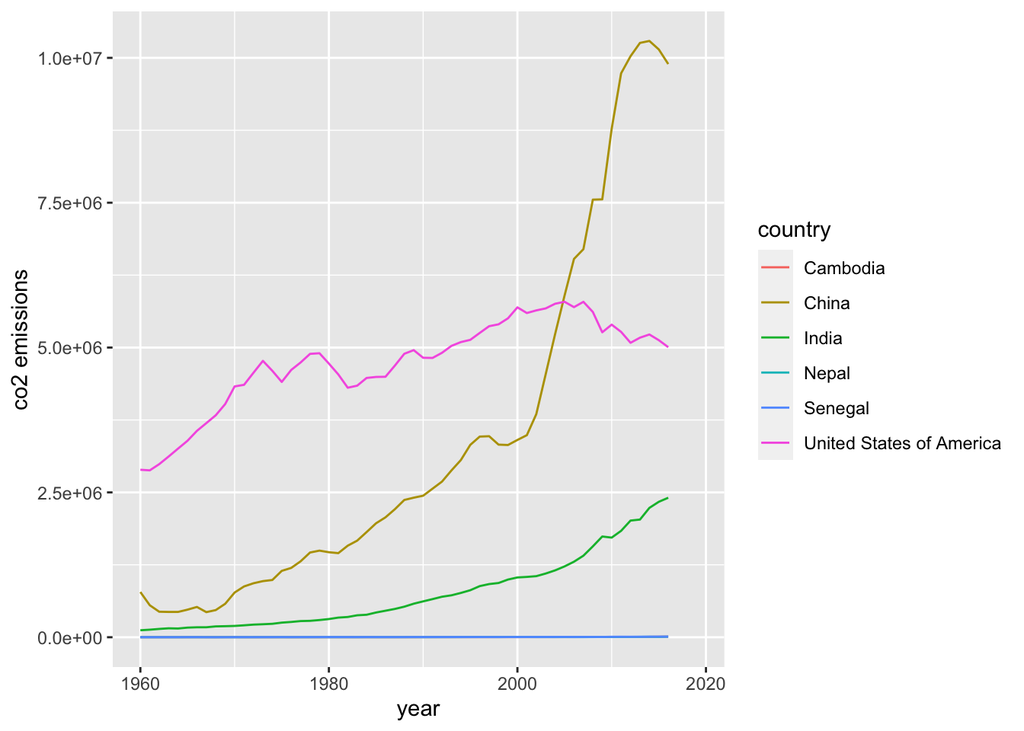

```r
gapminder %>%
filter(iso3 %in% c("USA", "CHN", "IND", "NPL", "SEN", "KHM")) %>%
ggplot(aes(time, co2, color = name)) +
geom_line() +
labs(x = "year", y = "co2 emissions", color = "country")
```